# Covid-19 awareness data analysis

Fatih KIYIKÇI

## Quiz and data gathering

I tried to make the quiz not too hard, but at the same time hard to get a 100 or 90 points, selected some of the questions and options to acquire both the knowledge and common sense of people. There was only one person that did not answered a question. Non-demographic Questions and response rates are:

Corona virüsün ölümcüllük seviyesi nedir? 37/37  
Koronavirüs’ün en yaygın belirtileri nelerdir? 37/37  
koronavirüs tanısı konulmuş biriyle temastan sonra ne yapılmalıdır? 37/37  
Koronavirüs belirtisi gösterenler ne yapmalı? 37/37  
Virüsten hijyenik olarak korunmak için hangileri yapılmalıdır? 37/37  
Koronavirüsten en ciddi etkilenen gruplar hangileridir? 37/37  
Hangileri koronavirüse karşı alınacak önlemler arasındadır? 37/37  
Covid-19 hastalığını tedavi edebilecek aşı, ilaç veya bir tedavi mevcut olarak bulunmakta mıdır? 36/37  
Hangisi koronavirüse karşı daha etkili bir yöntemdir? 37/37  
Covid-19 Hastalığını oluşturan virüsün adı nedir? 37/37

## Data Visualization

### Distribution of the scores according to the quiz taker’s age

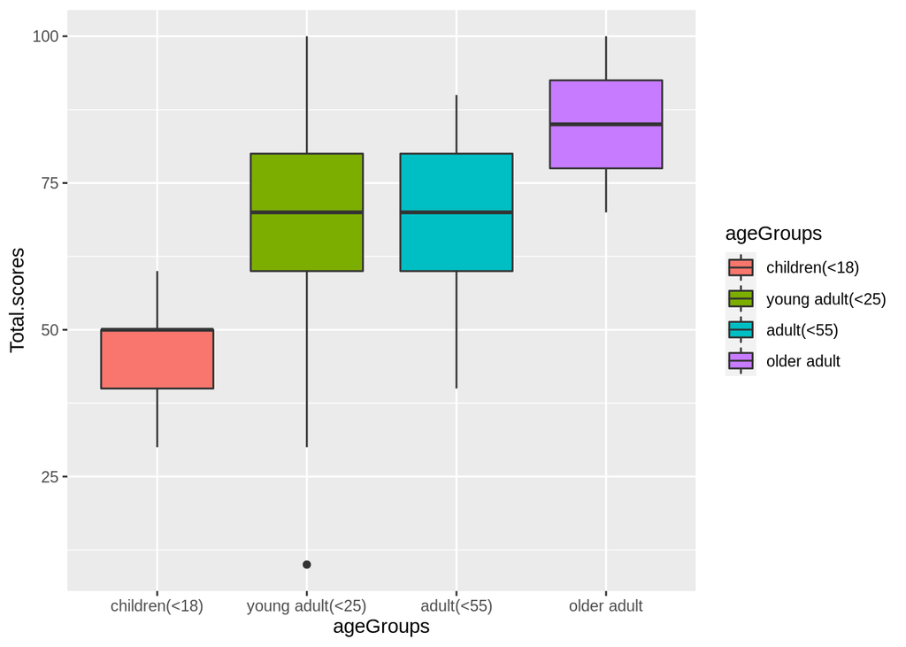

As seen in the visualization, the young adult and adult groups are very close in terms of their score, there are 2 age groups that stands out, which are children (<18) and older adults (>55). Children group has the lowest score in all four groups, which is expected. Older adults have the highest score of all four groups. Which is not much surprising since the virus is particularly dangerous for older people, but this is not much accountable, since there are only 2 samples from the older adult age group.

### Distribution of the Total.scores

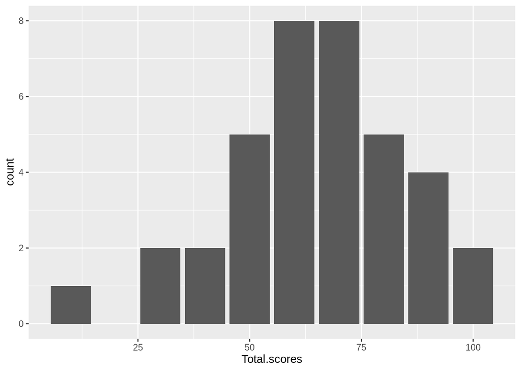

### Distribution of scores according to the quiz taker’s education level

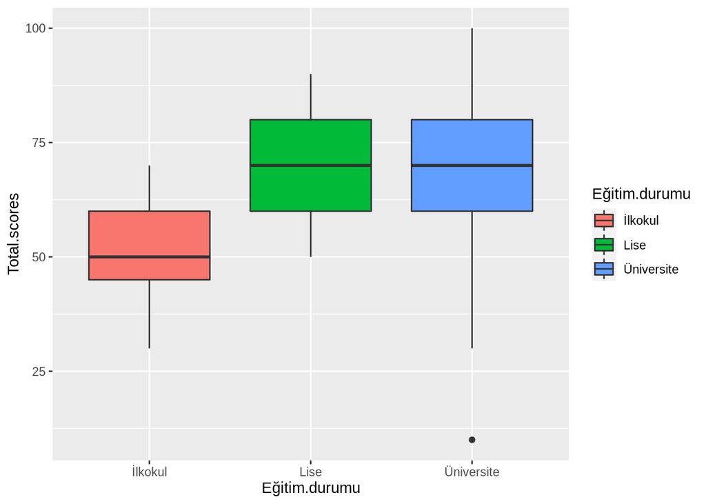

Unsurprisingly, we can see the samples with the lowest education level, which is ‘primary school’ doesn’t have as much success in the test as the people with higher education, But there seems to be not much difference between the ‘Highscool’ and ‘University’ education levels, other than the variation.

### Distribution of the scores with respect to the smoker/non-smoker property

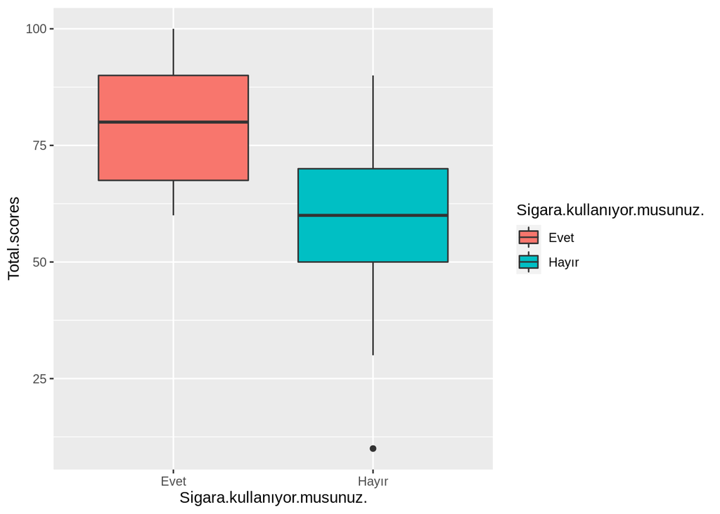

Interestingly, people who smoke has clearly more success at the test, It can be associated with some of the questions, we can further investigate the reason.

## Confidence Intervals

### Confidence interval and confidence interval plot, with respect to the gender of the quiz taker.

```
##          lower    upper
## Erkek 51.83954 76.39576
## Kadın 57.86187 73.13813
```

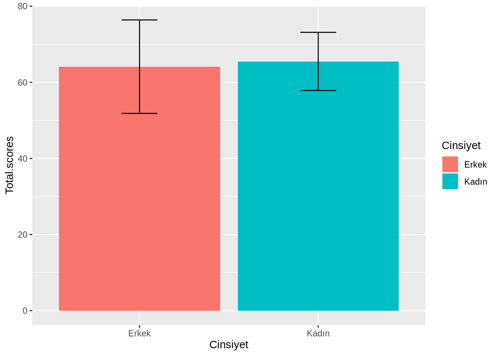

Looking at the confidence intervals, We can be %95 confident that the true mean for the male population is between 51.83954 and 76.39576.

We can be %95 confident that the true mean for the female population is between 57.86187 and 73.13813

We can see there is not much difference on the means for the genders, and the confidence interval for males is wider, this can be caused by the lack of information (as sample size) for males.

### Confidence interval and confidence interval plot, with respect to the education level of the quiz taker.

```
##               lower    upper
## Üniversite 57.99329 76.78932
## Lise       57.36055 82.63945
## İlkokul    39.40606 63.45108
```

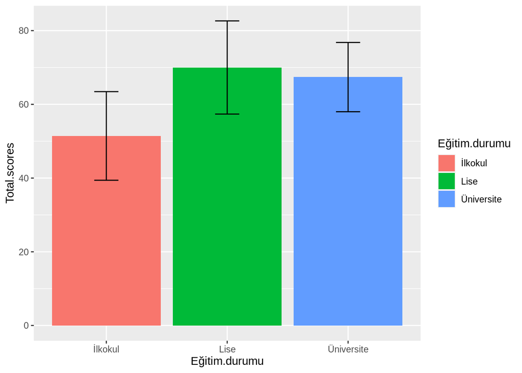

We can be %95 confident that the true mean for the population that has education level of High school is between 57.36055 and 82.63945

We can see the mean total scores of the three education levels, the mean total.scores of the samples that has education level of primary school is the lowest.

### Confidence intervals and confidence interval plots, with respect to the Faculty of the quiz taker.

```
##                               lower     upper
## Ziraat                     18.60013  74.73320
## Mühendislik                53.82629  84.35553
##                            49.61292  70.38708
## Tıp                              NA        NA
## Sağlık bilimleri                 NA        NA
## Eğitim                           NA        NA
## İktisadi ve İdari Bilimler 41.95369 108.04631
## Mimarlık                         NA        NA
## Edebiyat                         NA        NA
## İletişim                         NA        NA
## Spor Bilimleri                   NA        NA
```

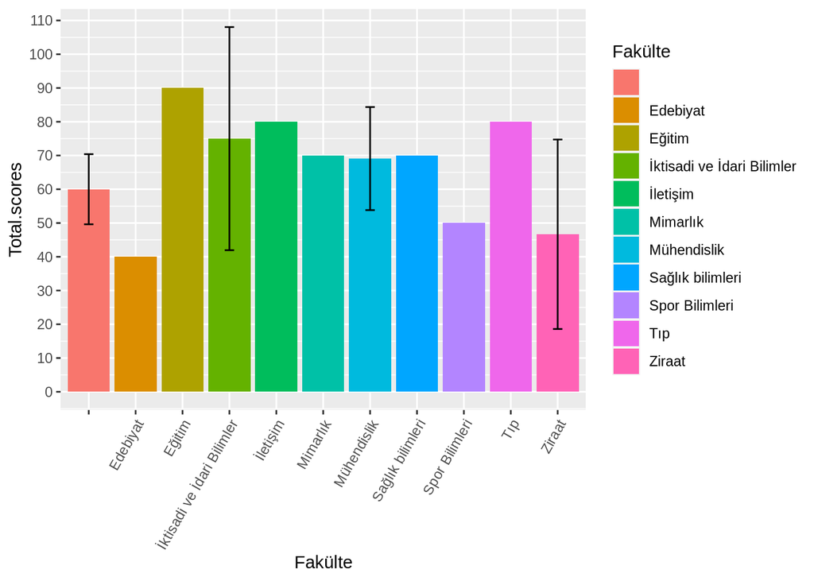

In the samples where the faculty of the quiz taker is; ‘Edebiyat’, ‘Eğitim’, ‘İletişim’, ‘Mimarlık’, ‘Sağlık Bilimleri’ and ‘Tıp’, there are only 1 samples each. Thus there are no confidence interval for those samples. The first bar, without the name is the samples for samples without the education level ‘University’.

# Hypothesis Testing

## Testing mean scores based on gender

### Normality testing

is the data normally distributed?  
Ho: data is normally distributed  
Ha: data is not normally distributed

```
## [1] "length of male samples: 17"
```

```
## [1] "length of female samples: 20"
```

```
##
##  Shapiro-Wilk normality test
##
## data:  Total.scores[Cinsiyet == "Erkek"]
## W = 0.96246, p-value = 0.6781
```

```
##
##  Shapiro-Wilk normality test
##
## data:  Total.scores[Cinsiyet == "Kadın"]
## W = 0.94833, p-value = 0.3424
```

p-value 0.6781, 0.3424 > 0.05, fail to reject the null hyphotesis,  
We assume both dataframes are normal

### Variance test

are variances the same for both sets?  
Ho: varMale == varFemale  
Ha: varMale != varFemale

```
##
##  F test to compare two variances
##
## data:  Total.scores[Cinsiyet == "Erkek"] and Total.scores[Cinsiyet == "Kadın"]
## F = 2.147, num df = 16, denom df = 19, p-value = 0.1137
## alternative hypothesis: true ratio of variances is not equal to 1
## 95 percent confidence interval:
##  0.8287488 5.7926705
## sample estimates:
## ratio of variances
##           2.147001
```

confidence interval for variances equality includes 1 [0.8287488, 5.7926705]  
p-value = 0.1137 > 0.05  
Fail to Reject Null  
We assume variances are equal.

### Testing a Hyphotesis

Let’s create a null hypothesis,  
Ho: mean scores of both male and female are the same muFemale = muMale  
An alternative hypothesis,  
Ha: mean scores of males and females are not the same. muFemale != muMale

```
##
##  Two Sample t-test
##
## data:  Total.scores[Cinsiyet == "Erkek"] and Total.scores[Cinsiyet == "Kadın"]
## t = -0.20726, df = 35, p-value = 0.837
## alternative hypothesis: true difference in means is not equal to 0
## 95 percent confidence interval:
##  -14.92231  12.15760
## sample estimates:
## mean of x mean of y
##  64.11765  65.50000
```

p-value = 0.837 > 0.05  
confidence interval includes mu=0. [-14.92231, 12.15760]  
t(o) (0.20726) < t(t) ~2  
Fail to reject Null  
There is no evidence that the true mean values for males and females is different.

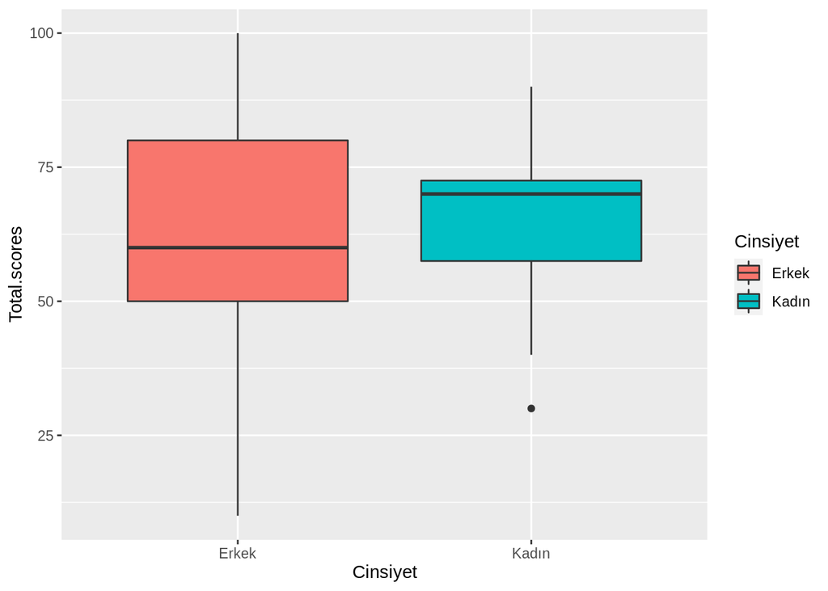

## Testing the answer to a specific question as smoker/non smoker

In the visualizations, an interesting result caught my attention; The smokers tend to have clearly better scores than non-smokers. This might be associated with the question; ‘Koronavirüsten en ciddi etkilenen gruplar hangileridir?’, which smoking is an answer option.

Since every question is worth of 10 points, i thought i could test an alternative hyphotesis: ‘The mean difference of Total.scores between smokers and non smokers is greater than 10’

### Normality test

is the data normally distributed?  
Ho: data is normally distributed  
Ha: data is not normally distributed

```
## [1] "length of smoking samples: 12"
```

```
## [1] "length of non-smoking samples: 25"
```

```
##
##  Shapiro-Wilk normality test
##
## data:  Total.scores[Sigara.kullanıyor.musunuz. == "Evet"]
## W = 0.89647, p-value = 0.1428
```

```
##
##  Shapiro-Wilk normality test
##
## data:  Total.scores[Sigara.kullanıyor.musunuz. == "Hayır"]
## W = 0.9511, p-value = 0.2654
```

p-value 0.1428, 0.2654 > 0.05 Fail to reject the null hyphotesis,  
We assume both dataframes are normal

### Variance test

are variances the same for both sets?  
Ho: varMale == varFemale  
Ha: varMale != varFemale

```
##
##  F test to compare two variances
##
## data:  Total.scores[Sigara.kullanıyor.musunuz. == "Evet"] and Total.scores[Sigara.kullanıyor.musunuz. == "Hayır"]
## F = 0.66297, num df = 11, denom df = 24, p-value = 0.4837
## alternative hypothesis: true ratio of variances is not equal to 1
## 95 percent confidence interval:
##  0.2563206 2.1032885
## sample estimates:
## ratio of variances
##          0.6629712
```

confidence interval for variances equality includes 1 [0.2563206, 2.1032885]  
p-value = 0.4837 > 0.05  
Fail to Reject Null  
We assume variances are equal.

### Testing a Hyphotesis

Let’s create a null hypothesis,  
Ho: difference in mean scores for smokers and non smokers is less than 10 muNonSmokers >= muSmokers-10 An alternative hypothesis,  
Ha: difference in mean scores for smokers and non smokers is greater or equal than 10

```
##
##  Two Sample t-test
##
## data:  Total.scores by Sigara.kullanıyor.musunuz.
## t = 1.8193, df = 35, p-value = 0.03872
## alternative hypothesis: true difference in means is greater than 10
## 95 percent confidence interval:
##  10.79602      Inf
## sample estimates:
##  mean in group Evet mean in group Hayır
##            79.16667            58.00000
```

Let’s look at a plot to see the answers for that particular question (‘Koronavirüsten en ciddi etkilenen gruplar hangileridir?’) described by the question; (‘Sigara kullanıyor musunuz?’)

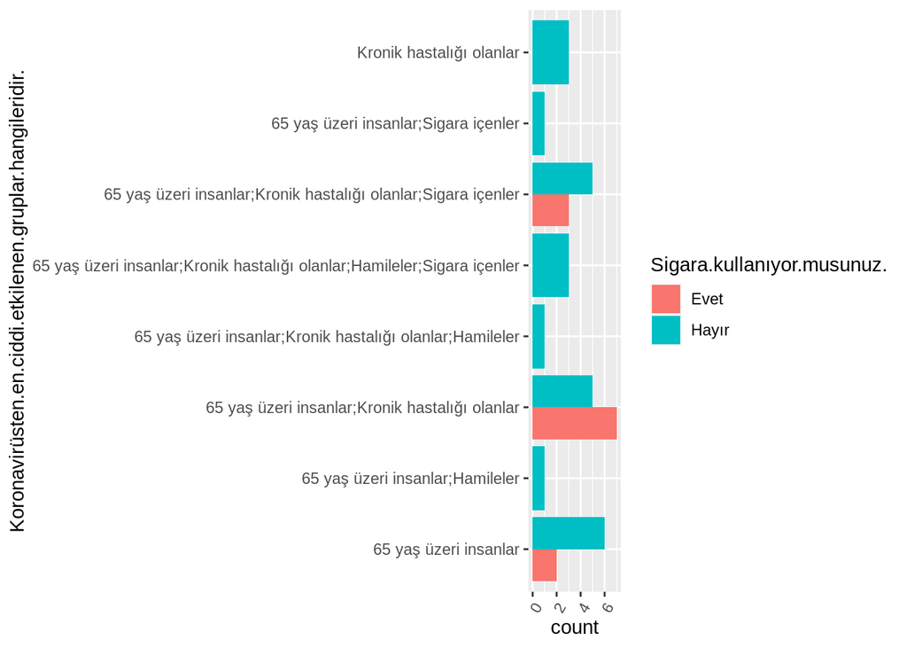

```
## [1] 5.833333 2.000000
```

As seen in the plot 9/25 non-smokers’ answers included the smokers and wrong.  
The mean score for the question, answered by the smokers is 5.83, same for non-smokers is 2.0.

This partially explains why non-smokers get lesser grades than smokers.

## Testing the total.score by age groups

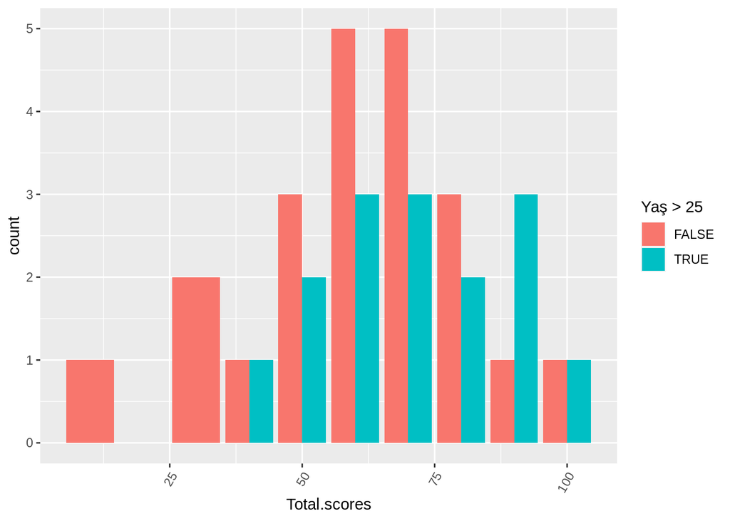

is the data normally distributed?  
Ho: data is normally distributed  
Ha: data is not normally distributed

```
## [1] "length of samples that are older than 25: 15"
```

```
## [1] "length of samples that are younger than 25: 22"
```

```
##
##  Shapiro-Wilk normality test
##
## data:  Total.scores[Yaş > 25]
## W = 0.96009, p-value = 0.6939
```

```
##
##  Shapiro-Wilk normality test
##
## data:  Total.scores[Yaş < 25]
## W = 0.96191, p-value = 0.5289
```

p-value 0.6939, 0.5289 > 0.05, Fail to reject the null hyphotesis,  
We assume both dataframes are normal

are variances the same for both sets?  
Ho: varMale == varFemale  
Ha: varMale != varFemale

```
##
##  F test to compare two variances
##
## data:  Total.scores[Yaş > 25] and Total.scores[Yaş < 25]
## F = 0.70139, num df = 14, denom df = 21, p-value = 0.5005
## alternative hypothesis: true ratio of variances is not equal to 1
## 95 percent confidence interval:
##  0.2735777 1.9836332
## sample estimates:
## ratio of variances
##          0.7013861
```

Let’s create a null hypothesis;

Ho: difference in mean total.scores of the age group > 25 and age < 25 is 0 An alternative hypothesis,  
Ha: difference in mean total.scores for age group > 25 and age < 25 is not equal to 0

```
##
##  Two Sample t-test
##
## data:  Total.scores[Yaş > 25] and Total.scores[Yaş < 25]
## t = 1.4851, df = 35, p-value = 0.1465
## alternative hypothesis: true difference in means is not equal to 0
## 95 percent confidence interval:
##  -3.580581 23.095733
## sample estimates:
## mean of x mean of y
##  70.66667  60.90909
```

## ANOVA test

### Test the total.score value by education level (3 groups)

Ho: data is normally distributed Ha: data is not normally distributed

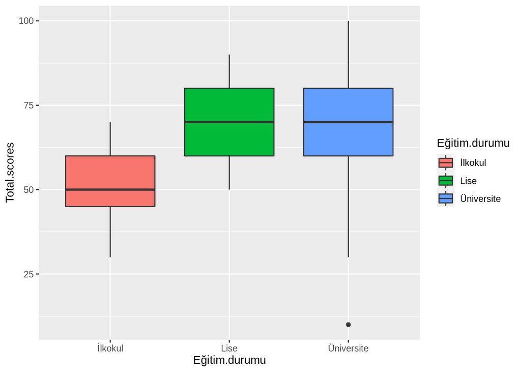

```
##
##  Shapiro-Wilk normality test
##
## data:  Total.scores[Eğitim.durumu == "İlkokul"]
## W = 0.96664, p-value = 0.8733
```

```
##
##  Shapiro-Wilk normality test
##
## data:  Total.scores[Eğitim.durumu == "Lise"]
## W = 0.95244, p-value = 0.7518
```

```
##
##  Shapiro-Wilk normality test
##
## data:  Total.scores[Eğitim.durumu == "Üniversite"]
## W = 0.94304, p-value = 0.2088
```

Variance homogenety H0:var1=var2=var3 Ha:At least one of them is different

```
##
##  Bartlett test of homogeneity of variances
##
## data:  Total.scores by Eğitim.durumu
## Bartlett's K-squared = 2.7418, df = 2, p-value = 0.2539
```

## Analysis of variance

```
##             (Intercept)       Eğitim.durumuLise Eğitim.durumuÜniversite
##                51.42857                18.57143                15.96273
```

```
##               Df Sum Sq Mean Sq F value Pr(>F)
## Eğitim.durumu  2   1595   797.6    2.13  0.134
## Residuals     34  12729   374.4
```

## Posthoc test to find which one is different.

```
##   Tukey multiple comparisons of means
##     95% family-wise confidence level
##
## Fit: aov(formula = Total.scores ~ Eğitim.durumu)
##
## $Eğitim.durumu
##                         diff        lwr      upr     p adj
## Lise-İlkokul       18.571429  -6.772284 43.91514 0.1862559
## Üniversite-İlkokul 15.962733  -4.504162 36.42963 0.1509843
## Üniversite-Lise    -2.608696 -23.075590 17.85820 0.9477298
```

### Anova model plots.

We have already tested the assumptions needed for the anova test, But the assumptions can also be tested using the plots.

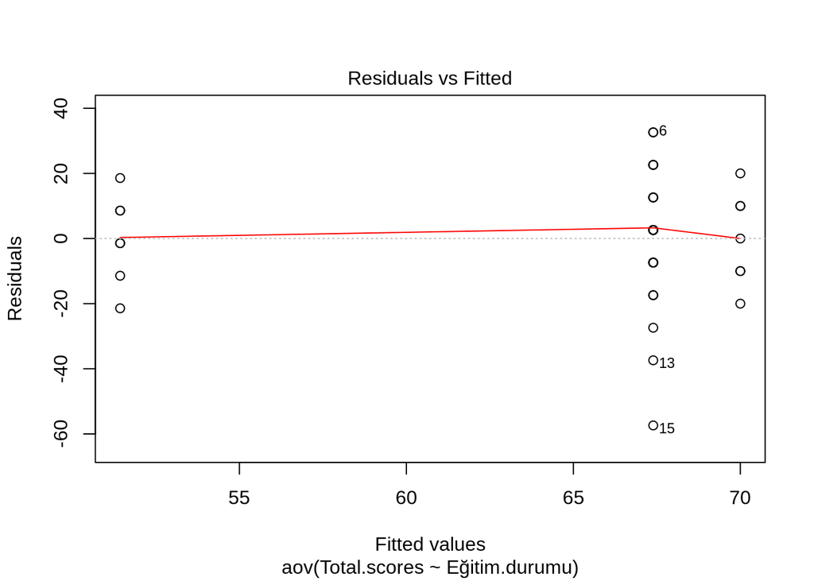

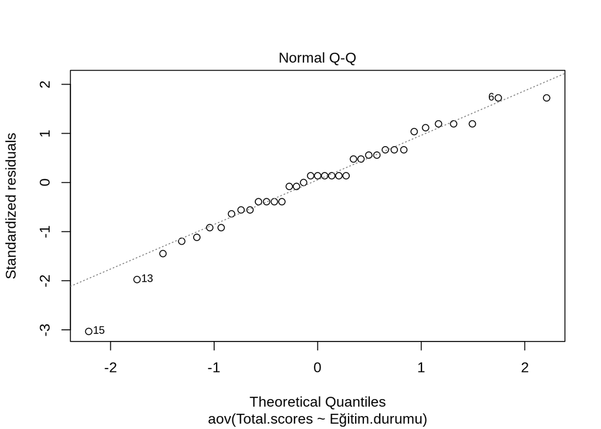

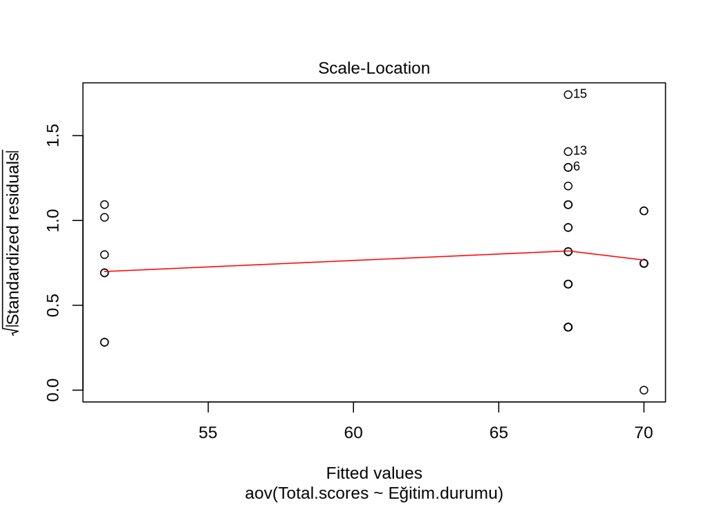

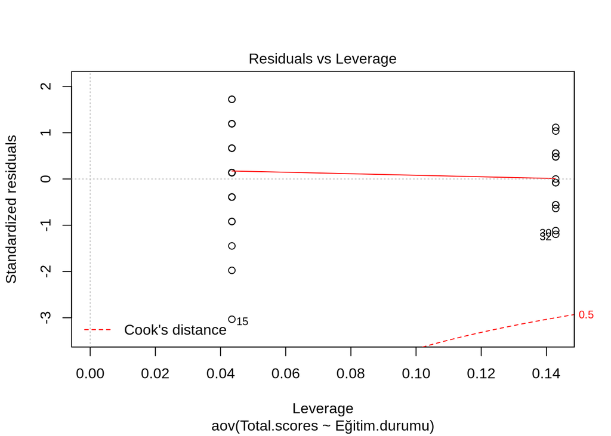